# Is post-operative non-weight-bearing necessary? Study protocol for a pragmatic randomised multicentre trial of operatively treated ankle fracture (DoWeCAST?)

Dr Brendan Palmer

25 June, 2020

## Background

Post-operative management regimes vary following open reduction and internal fixation (ORIF) of unstable ankle fractures. There is an evolving understanding that extended periods of immobilisation and limitation of weight-bearing may lead to poorer clinical outcomes. Traditional non-weight bearing cast immobilisation may prevent loss of fixation, and this practice continues in many centres.

The purpose of this trial is to investigate the safety and efficacy of immediate weight-bearing (IWB) and range of motion (ROM) exercise regimes following ORIF of unstable ankle fractures with a particular focus on functional outcomes and complication rates.

### Data summary

**Table 1. Patient demographics**

| Variable | Mean SD | (Min, Max) | Variable | Mean SD | (Min, Max) |
| --- | --- | --- | --- | --- | --- |
| arm |  |  | arm |  |  |
| Cast | 0 (0%) |  | Cast | 80 (100%) |  |
| Boot | 80 (100%) |  | Boot | 0 (0%) |  |
| age | 44.7 ± 16.5 | (15.2, 94) | age | 46.4 ± 18 | (16.1, 83.7) |
| type_of_implant |  |  | type_of_implant |  |  |
| 0-1-2 | 3 (3.8%) |  | 0-1-2 | 3 (3.8%) |  |
| 0-1-2-3 | 1 (1.3%) |  | 0-1-2-3 | 2 (2.5%) |  |
| 0-1-3 | 12 (15%) |  | 0-1-3 | 5 (6.2%) |  |
| 0-1 | 19 (23.8%) |  | 0-1 | 20 (25%) |  |
| 0-1-2-6 | 0 (0%) |  | 0-1-2-6 | 1 (1.3%) |  |
| 3-9 | 2 (2.5%) |  | 3-9 | 3 (3.8%) |  |
| 0-1-5-9 | 4 (5%) |  | 0-1-5-9 | 0 (0%) |  |
| 1-9 | 1 (1.3%) |  | 1-9 | 2 (2.5%) |  |
| 9 | 3 (3.8%) |  | 9 | 4 (5%) |  |
| 2-3-8 | 1 (1.3%) |  | 2-3-8 | 0 (0%) |  |
| 0-1-9 | 6 (7.5%) |  | 0-1-9 | 6 (7.5%) |  |
| 0-1-2-9 | 1 (1.3%) |  | 0-1-2-9 | 6 (7.5%) |  |
| 1-2-3 | 1 (1.3%) |  | 1-2-3 | 0 (0%) |  |
| 4 | 0 (0%) |  | 4 | 1 (1.3%) |  |
| 1-2-9 | 1 (1.3%) |  | 1-2-9 | 4 (5%) |  |
| 2-3-9 | 1 (1.3%) |  | 2-3-9 | 1 (1.3%) |  |
| 3-7 | 1 (1.3%) |  | 3-7 | 0 (0%) |  |
| 3-5-9 | 1 (1.3%) |  | 3-5-9 | 0 (0%) |  |
| 6-9-11 | 1 (1.3%) |  | 6-9-11 | 0 (0%) |  |
| 0-2-4 | 0 (0%) |  | 0-2-4 | 1 (1.3%) |  |
| 0-1-5 | 1 (1.3%) |  | 0-1-5 | 3 (3.8%) |  |
| 5 | 0 (0%) |  | 5 | 1 (1.3%) |  |
| 2-4-9 | 0 (0%) |  | 2-4-9 | 1 (1.3%) |  |
| 1-2 | 3 (3.8%) |  | 1-2 | 0 (0%) |  |
| 3 | 2 (2.5%) |  | 3 | 1 (1.3%) |  |
| 1 | 3 (3.8%) |  | 1 | 1 (1.3%) |  |
| 4-6-9 | 0 (0%) |  | 4-6-9 | 1 (1.3%) |  |
| 0-1-2-5 | 0 (0%) |  | 0-1-2-5 | 1 (1.3%) |  |
| 1-2-5-9 | 1 (1.3%) |  | 1-2-5-9 | 0 (0%) |  |
| 0-1-3-5 | 1 (1.3%) |  | 0-1-3-5 | 0 (0%) |  |
| 0-1-3-9 | 2 (2.5%) |  | 0-1-3-9 | 2 (2.5%) |  |
| 1-5 | 2 (2.5%) |  | 1-5 | 1 (1.3%) |  |
| 1-3-9-12 | 1 (1.3%) |  | 1-3-9-12 | 0 (0%) |  |
| 0-7 | 0 (0%) |  | 0-7 | 1 (1.3%) |  |
| 0-9 | 0 (0%) |  | 0-9 | 2 (2.5%) |  |
| 1-2-10 | 1 (1.3%) |  | 1-2-10 | 0 (0%) |  |
| 2-3 | 1 (1.3%) |  | 2-3 | 1 (1.3%) |  |
| 1-5-9 | 0 (0%) |  | 1-5-9 | 1 (1.3%) |  |
| 1-3-9 | 0 (0%) |  | 1-3-9 | 2 (2.5%) |  |
| 2 | 0 (0%) |  | 2 | 1 (1.3%) |  |
| 1-2-5 | 0 (0%) |  | 1-2-5 | 1 (1.3%) |  |
| 0-4 | 1 (1.3%) |  | 0-4 | 0 (0%) |  |
| 6-7 | 1 (1.3%) |  | 6-7 | 0 (0%) |  |
| 4-9 | 1 (1.3%) |  | 4-9 | 0 (0%) |  |
| surgeon |  |  | surgeon |  |  |
| 0 | 24 (30%) |  | 0 | 30 (37.5%) |  |
| 1 | 56 (70%) |  | 1 | 50 (62.5%) |  |
| site |  |  | site |  |  |
| R | 38 (47.5%) |  | R | 48 (60%) |  |
| L | 42 (52.5%) |  | L | 32 (40%) |  |
| hospital_stay | 1 ± 1.5 | (0, 12) | hospital_stay | 1.5 ± 2.5 | (0, 19) |

Note: Lefthand side - Boot, Righthand side - Cast

### Primary outcome: Olerud-Molander Ankle Score (OMAS)

**Table 2. Summary of OMAS scores across all sampling points**

| Arm | Sampling point | Mean | SD | Min | Median | Max | Valid data points |
| --- | --- | --- | --- | --- | --- | --- | --- |
| Cast | 14d | 23.44 | 17.18 | 0 | 22.5 | 65 | 64 |
| Boot | 14d | 26.97 | 17.67 | 0 | 25.0 | 75 | 66 |
| Cast | 42d | 34.07 | 18.70 | 0 | 35.0 | 70 | 59 |
| Boot | 42d | 44.07 | 25.30 | 0 | 40.0 | 100 | 59 |
| Cast | 90d | 52.74 | 21.73 | 5 | 57.5 | 90 | 42 |
| Boot | 90d | 60.55 | 25.61 | 3 | 62.5 | 100 | 42 |
| Cast | 180d | 72.50 | 26.01 | 5 | 72.5 | 100 | 26 |
| Boot | 180d | 71.67 | 24.18 | 30 | 70.0 | 100 | 27 |
| Cast | 365d | 72.78 | 26.23 | 20 | 75.0 | 100 | 9 |
| Boot | 365d | 70.00 | 27.55 | 25 | 62.5 | 100 | 12 |

**Fig. OMAS density plots by sampling point**

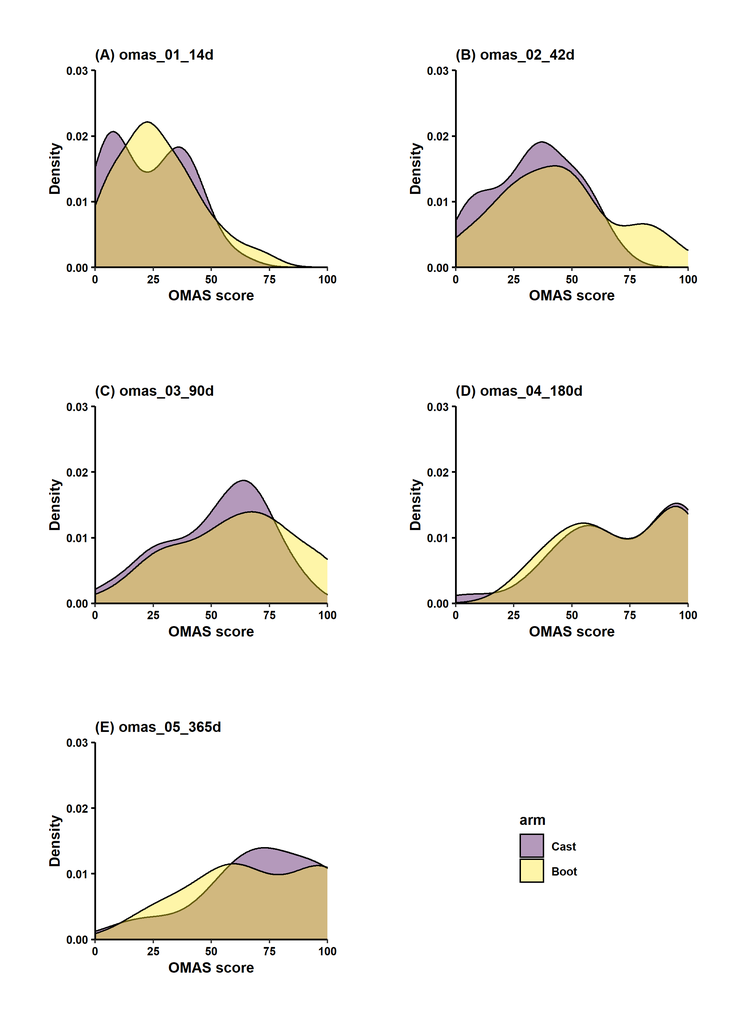

Note: The density plot is a representation of the distribution of a numeric variable akin to a histrgram. The data is fed to a probabilty density function to give it the smooth appearence. Again, we need to recognise that more data points are available for earlier periods in the study at the present time.

**Table 3. Summary of SF36 physical health data across all sampling points**

| Arm | Sampling point | Mean | SD | Min | Median | Max | Valid data points |
| --- | --- | --- | --- | --- | --- | --- | --- |
| Cast | 14d | 29.36 | 6.20 | 16.75 | 28.53 | 43.03 | 55 |
| Boot | 14d | 29.60 | 8.37 | 12.63 | 28.64 | 61.72 | 57 |
| Cast | 42d | 32.30 | 8.16 | 19.75 | 30.50 | 56.52 | 55 |
| Boot | 42d | 33.39 | 9.52 | 16.86 | 32.34 | 58.26 | 58 |
| Cast | 90d | 40.31 | 8.01 | 26.01 | 40.55 | 57.35 | 40 |
| Boot | 90d | 41.47 | 11.40 | 16.39 | 41.49 | 58.41 | 45 |
| Cast | 180d | 42.84 | 12.58 | 21.35 | 42.05 | 60.18 | 28 |
| Boot | 180d | 46.67 | 10.52 | 28.13 | 50.27 | 58.36 | 30 |
| Cast | 365d | 42.32 | 14.79 | 22.28 | 38.84 | 61.94 | 9 |
| Boot | 365d | 46.70 | 11.35 | 24.84 | 48.41 | 63.82 | 12 |

**Table 4. Summary of SF36 mental health data across all sampling points**

| Arm | Sampling point | Mean | SD | Min | Median | Max | Valid data points |
| --- | --- | --- | --- | --- | --- | --- | --- |
| Cast | 14d | 43.42 | 9.87 | 15.54 | 42.24 | 66.78 | 55 |
| Boot | 14d | 43.48 | 13.73 | 10.34 | 42.27 | 65.29 | 57 |
| Cast | 42d | 42.64 | 10.46 | 20.91 | 42.77 | 64.07 | 55 |
| Boot | 42d | 44.83 | 11.26 | 19.90 | 44.90 | 62.73 | 58 |
| Cast | 90d | 47.41 | 9.70 | 14.72 | 48.19 | 64.29 | 40 |
| Boot | 90d | 47.66 | 11.15 | 16.54 | 50.77 | 60.41 | 45 |
| Cast | 180d | 47.14 | 14.18 | 5.69 | 49.76 | 66.87 | 28 |
| Boot | 180d | 49.95 | 9.32 | 28.35 | 53.36 | 60.44 | 30 |
| Cast | 365d | 48.20 | 10.53 | 31.77 | 48.45 | 60.62 | 9 |
| Boot | 365d | 44.87 | 11.26 | 21.67 | 48.97 | 56.05 | 12 |

There did not appear to be any noticable difference between study arms with respect tothe SF36 physical health or SF36 mental health assessments.

## Proportional odds model of OMAS function

As such, alternatives to traditional statistical methods such as t-tests and linear models should be considered in this instance. In the following example a proportional odds model has been employed.

**Models were constructed of the form:**

`OMAS reading ~ Study arm + rcs(age, 3) + Length of hospital stay`

**Table 5. Prliminary outputs of the proportional odds model for OMAS readings at 2 weeks and 6 weeks**

| variable | rho | R2 | p_value |
| --- | --- | --- | --- |
| po_omas_2wk | 0.1055 | 0.0139 | 0.776 |
| po_omas_6wk | 0.3400 | 0.1466 | < 0.001 |

## Linear model of OMAS function

**Models were constructed of the form:**

`OMAS reading ~ Study arm + age + Length of hospital stay`

**Table 6. Prliminary outputs of linear regression OMAS readings at 2 weeks and 6 weeks**

| Variable | estimate | std.error | statistic | p.value | 2.5 % | 97.5 % |
| --- | --- | --- | --- | --- | --- | --- |
| Boot - 2wks | 2.887 | 3.168 | 0.9112 | 0.364 | -3.384 | 9.158 |
| Boot - 6wks | 9.496 | 4.048 | 2.3459 | 0.021 | 1.476 | 17.516 |

### Preliminary summary of the analysis

2 weeks post-surgery: Mean OMAS score for the boot was 2.9 units higher than with the cast (95% CI -3.38, 9.16) p = 0.364.

6 weeks post-surgery: Mean OMAS score for the boot was 9.5 units higher than with the cast (95% CI 1.48, 17.52) p = 0.021.